# index

Adya Joshi | Amanda Li | Team Double A  
Final Project | CMSC320, Fall 2022

**"The heavens (Amanda & Adya) themselves blaze forth the death (positive COVID test) of princes (Maryland Residents)"** An analysis of COVID-19 case numbers by Zip Code in Maryland

“The fault, dear Brutus, is not in our stars, but in ourselves, that we are underlings (to the natural spread of an airborne virus).” Since the start of the pandemic, many have been eager to blame anything and everything for COVID and it's effects. Perhaps it's comforting for people to think that they were victim to a "rare conjuction between Pluto and Saturn [(in Capricorn!!!)](https://tif.ssrc.org/2020/08/13/placing-the-pandemic-in-time-astrology-and-covid-19/)" and not basic infectious disease. On the other side, many have been taking the raw data and making sense of it from the beginning in an effort to rationalize an existence that refutes them at every step of the way. So, why continue to try and make sense of something that everyone else is obsessed with? Simple, the Regina George effect, why not try and find out more about the popular girl? Analyzing Covid data can give citizens and goernment officials important insights into the disease, its spread, and effect of preventive measures. We also wanted to be able to see and analyze this data for ourselves since the pandemic and the data behind it has been a hot topic, and now we have the skills to understand it on our own. In our project, we look at a dataset of daily(ish) covid case totals by zipcode in Maryland and try and a get a picture of covid cases throughout time in Maryland starting from January 1, 2022 to November 14, 2022. We then get a little bit more specific and look at the case data from January 5th, 2022 and compare it to demographic data in Maryland. Now, you may be wondering why January 5th? The reason why is because the highest reported number of covid deaths in Maryland was on [January 19, 2022](https://covid19.healthdata.org/united-states-of-america/maryland?view=daily-deaths&tab=trend). Deaths tend to lag behind cases by about two weeks, which in this case would be January 5th. Below is the tutorial describing how we created a pipeline to ingest, clean, analyze and visualize this data and what you can do further.

```python
import folium
import requests
import pandas
from matplotlib import pyplot as plt, dates as mdates
import numpy as np
import math
from sklearn.linear_model import LinearRegression
from datetime import datetime as dt
from datetime import timedelta
from scipy.stats import pearsonr

# Initial dataset just contains COVID cases by ZIP code, 1/1/2022 to 11/14/2022
data = pandas.read_csv("MD_COVID-19_-_Cases_by_ZIP_Code.csv", dtype = {'ZIP_CODE' : 'str'})
data = data.rename(columns = {"ZIP_CODE" : "ZIP"})
data = data.dropna()
data
```

|  | OBJECTID | ZIP | total01_01_2022 | total01_02_2022 | total01_03_2022 | total01_04_2022 | total01_05_2022 | total01_06_2022 | total01_07_2022 | total01_08_2022 | ... | total10_27_2022 | total10_28_2022 | total10_31_2022 | total11_01_2022 | total11_02_2022 | total11_03_2022 | total11_04_2022 | total11_07_2022 | total11_09_2022 | total11_14_2022 |
| --- | --- | --- | --- | --- | --- | --- | --- | --- | --- | --- | --- | --- | --- | --- | --- | --- | --- | --- | --- | --- | --- |
| 7 | 525 | 20602 | 3755.0 | 3834.0 | 3941.0 | 4014.0 | 4055.0 | 4105.0 | 4140.0 | 4214.0 | ... | 6631.0 | 6636.0 | 6639.0 | 6646.0 | 6652.0 | 6659.0 | 6665.0 | 6669.0 | 6678.0 | 6694.0 |
| 8 | 526 | 20603 | 3851.0 | 3946.0 | 4049.0 | 4127.0 | 4185.0 | 4277.0 | 4328.0 | 4441.0 | ... | 7502.0 | 7507.0 | 7518.0 | 7534.0 | 7535.0 | 7539.0 | 7543.0 | 7550.0 | 7563.0 | 7575.0 |
| 9 | 527 | 20604 | 55.0 | 56.0 | 57.0 | 59.0 | 60.0 | 61.0 | 61.0 | 61.0 | ... | 91.0 | 91.0 | 91.0 | 91.0 | 91.0 | 91.0 | 91.0 | 91.0 | 91.0 | 91.0 |
| 10 | 528 | 20606 | 28.0 | 28.0 | 28.0 | 28.0 | 28.0 | 31.0 | 31.0 | 32.0 | ... | 57.0 | 57.0 | 57.0 | 57.0 | 57.0 | 57.0 | 57.0 | 57.0 | 57.0 | 57.0 |
| 11 | 529 | 20607 | 1559.0 | 1602.0 | 1640.0 | 1671.0 | 1698.0 | 1739.0 | 1757.0 | 1792.0 | ... | 2876.0 | 2878.0 | 2881.0 | 2889.0 | 2892.0 | 2894.0 | 2894.0 | 2894.0 | 2899.0 | 2911.0 |
| ... | ... | ... | ... | ... | ... | ... | ... | ... | ... | ... | ... | ... | ... | ... | ... | ... | ... | ... | ... | ... | ... |
| 509 | 1027 | 21915 | 246.0 | 247.0 | 250.0 | 252.0 | 257.0 | 259.0 | 262.0 | 270.0 | ... | 425.0 | 425.0 | 425.0 | 425.0 | 425.0 | 425.0 | 425.0 | 426.0 | 427.0 | 428.0 |
| 510 | 1028 | 21917 | 216.0 | 218.0 | 220.0 | 225.0 | 229.0 | 231.0 | 236.0 | 237.0 | ... | 444.0 | 444.0 | 444.0 | 445.0 | 445.0 | 445.0 | 445.0 | 445.0 | 445.0 | 446.0 |
| 511 | 1029 | 21918 | 381.0 | 384.0 | 385.0 | 392.0 | 398.0 | 404.0 | 423.0 | 429.0 | ... | 676.0 | 676.0 | 679.0 | 679.0 | 679.0 | 680.0 | 680.0 | 680.0 | 682.0 | 682.0 |
| 512 | 1030 | 21919 | 290.0 | 292.0 | 294.0 | 301.0 | 305.0 | 314.0 | 323.0 | 329.0 | ... | 463.0 | 463.0 | 463.0 | 464.0 | 464.0 | 464.0 | 464.0 | 464.0 | 465.0 | 465.0 |
| 513 | 1031 | 21921 | 5064.0 | 5120.0 | 5160.0 | 5279.0 | 5334.0 | 5382.0 | 5463.0 | 5527.0 | ... | 8774.0 | 8784.0 | 8786.0 | 8795.0 | 8800.0 | 8803.0 | 8809.0 | 8813.0 | 8821.0 | 8834.0 |

467 rows × 252 columns

In this first step, we import all of the necessary packages, libraries, modules, etc. We then import in our initial data file which we downloaded as a CSV file from [data.gov](https://catalog.data.gov/dataset/md-covid-19-cases-by-zip-code). This is the initial data ingestion step of the pipeline. Since we pulled our data on November 14, 2022, that is when our data ends, but if you pull it now, the cases will reflect a more recent update. We'll make use of this updating property in the future. Since pandas automatically assigns types to columns unless specified, we specified the type of the ZIP code to be a string. Pandas automatically took the zip code to be a number and since some zipcodes began or ended with a zero, this changed them. Keeping the string formatting allowed for accurate representations of the zip code. We also renamed the column for ease of use in future parts. There are a few ways to deal with missing values, however given the size of our dataset, we decided it would be best to drop any missing values using the dropna() function in pandas. So this cleans the data for a basic visualization. I would recommend against other methods, like filling in the average, for this dataset, since it is very location specific and we want to use the locations in our visualizations. If one was looking at this for purely statistic purposes, perhaps a different method of imputation might make sense. This [article](https://towardsdatascience.com/7-ways-to-handle-missing-values-in-machine-learning-1a6326adf79e) explains these in detail, so you can decide if your analysis would be better suited with a different method.

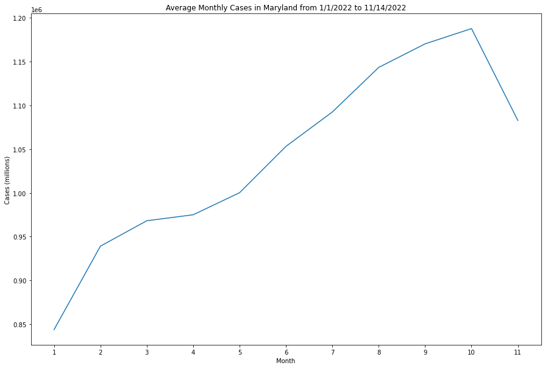

```python
### FIGURE 1: Average per month ###
# Creates groups by month
re = '^total(\d{2}).*$'
grouped = data.groupby(data.columns.str.extract(re, expand=False), axis=1)
monthly_avg = []

# Finds average for each month
for name, group in grouped:
    m_avg = group.sum(axis=0)
    m_avg = m_avg.drop(m_avg.index[0])

    # gets average per month
    m_avg = m_avg.sum() / len(group.columns)
    monthly_avg.append(m_avg)

# Graphs monthly average of cases across all of Maryland
plt.figure(figsize=(15,10))
plt.xlabel("Month")
plt.ylabel("Cases (millions)")
plt.title("Average Monthly Cases in Maryland from 1/1/2022 to 11/14/2022")
x = np.array([1, 2, 3, 4, 5, 6, 7, 8, 9, 10, 11])
plt.xticks(np.arange(1, 12, 1))
plt.plot(x, monthly_avg)
plt.show()
```

This next part shows two visualizations related to the raw data that we read in earlier. The visualization above looks at the average cases per month over the year in Maryland. This was done by grouping together the individual day counts for each zip code using groupby and then finding the average for the month for that zip code. The averages for all the zipcodes were then added to get an average for the state. One can see that cases were on rise until about October which is when they started to fall.

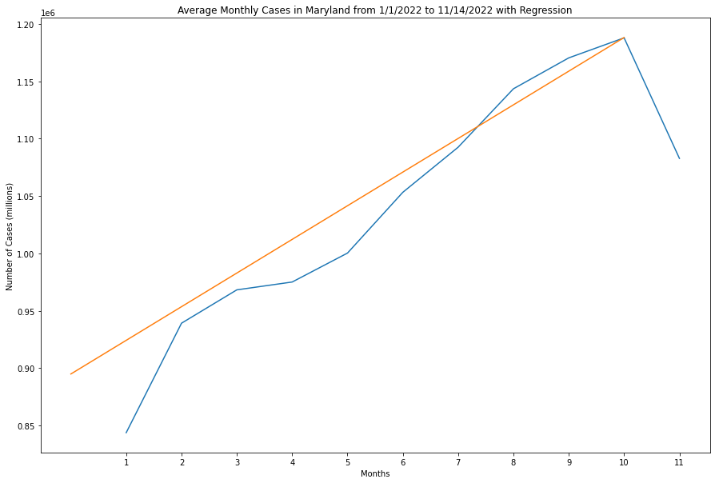

```python
### FIGURE 2: Average per month with regression line ###

# Regression model of monthly average
model = LinearRegression()
x = x.reshape(-1, 1)
model.fit(x, monthly_avg)
Y_pred = model.predict(x)

plt.figure(figsize=(15,10))
plt.xlabel("Months")
plt.ylabel("Number of Cases (millions)")
plt.title("Average Monthly Cases in Maryland from 1/1/2022 to 11/14/2022 with Regression")
plt.xticks(np.arange(1, 12, 1))
plt.plot(x, monthly_avg, Y_pred)
plt.show()
```

In the follow-up analysis and visualization, we first create a Linear Regression model using scikit-learn, although there are a [few other ways](https://towardsdatascience.com/introduction-to-linear-regression-in-python-c12a072bedf0) to do this as well. The basic idea for a linear regression model doesn't change, but if you have certain aspects you like better, you can change them as well. For example, statsmodels gives a lot of extra data with its regression model that scikit-learn or doing it on your own won't give. When picking how to do regression, you should think about how you plan to use your regression in your analysis. Since we only wanted to show the model and how well it held up to actual numbers in December, we went with sci-kitlearn over statsmodels.

```python
# Our dataset only includes cases from January to November, therefore using our regression model, we can predict the
# number of average monthly cases in December.
X_predict = [[12]]
pred = model.predict(X_predict)
print("Predicted average number of cases in December:" + str(pred))

# Compare our figure to most up-to-date data, up to December 13
decdata = pandas.read_csv('uptodatecovid.csv')
decdata = decdata.rename(columns = {"ZIP_CODE" : "ZIP"})
decdata = decdata.dropna()
decdata = decdata.reset_index()

dec_cols = [col for col in decdata.columns if 'total12' in col]

# Calculates average cases in December
sum = 0
for col in dec_cols:
    sum += decdata[col].sum()

dec_avg = sum / len(dec_cols)
print("Actual average number of cases in December: " + str(dec_avg))
print("Residual = observed - predicted cases in December: " + str(dec_avg - pred))
```

```
Predicted average number of cases in December:[1217370.91059282]
Actual average number of cases in December: 1284612.888888889
Residual = observed - predicted cases in December: [67241.97829607]
```

The next step is to see how well our model held up. As I mentioned earlier, this dataset does automatically update, so we took a more recent version and compared it to our model. As you can see, there were more cases in December than predicted, which lines up with reported trends of [increasing hospitalizations and cases nationwide](https://www.cnbc.com/2022/12/09/covid-and-flu-hospitalizations-increasing-rsv-declining.html). However, our residual shows that the model was not too far off.

This is the end of our analysis of the raw data. We wanted to be able to compare this data with other factors that have been discussed as external factors in the spread of covid. Unfortunately, we didn't track the stars and see how that impacted the case numbers, instead we took [census data by zipcode](https://data.imap.maryland.gov/datasets/maryland::maryland-census-data-zip-code-tabulation-areas-zctas/about) from Maryland.gov and looked at the race data from that. The census data has many other factors that can also be examined -- education level, income level etc. However, healthcare disparities due to race have been discussed, and we wanted to do a simple analysis.

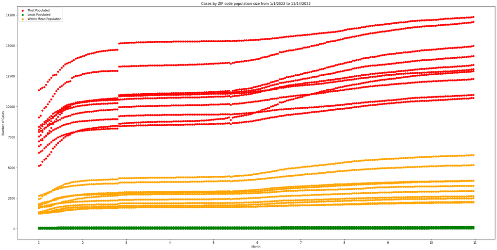

```python
### FIGURE 3: Scatterplot of proportion of cases/population ###

#Get additional demographic data, append to original dataframe by ZIP code
loc = pandas.read_csv("zipcode.csv", dtype = {'ZIP' : 'str'})
census = pandas.read_csv("census.csv", dtype = {'ZCTA5N' : 'str'})
census = census.rename(columns = {"ZCTA5N" : "ZIP", "POP100": "Population", "NHW": "White", "NHB": "Black", "NHAI": "Native American",
                                "NHA": "Asian", "NHNH": "Native Hawaiian", "NHO": "Other", "NHT": "Total Non-Hispanic", "HISP": "Hispanic",
                                "PNHW": "% White", "PNHB": "% Black", "PNHAI": "% Native American", "PNHA": "% Asian", "PNHNH": "% Native Hawaiian",
                                "PNHO": "% Other", "PNHT": "% Total Non-Hispanic", "PHISP": "% Hispanic", "POP65_": "Population 65+",
                                "PCTPOP65_": "% Population 65+", "MEDAGE": "Median Age", "PHOWN": "Homeowner Rate", "PLT18SP": "% Population under 18",
                                 })
census = census.drop(columns=['OBJECTID_1', 'ZCTA5CE10', 'FIRST_STAT', 'FIRST_GEOI', 'FIRST_CLAS', 'FIRST_MTFC', 'FIRST_FUNC',
                             'STATE', 'AREALAND', 'AREAWATR', 'HU100', 'VACNS', 'PVACNS', 'PWOMORT', 'PRENT',
                             'REPORT_2_P', 'REPORT_9_P', 'Shape_Length', 'Shape_Area'])
loccen = pandas.merge(loc, census, on = 'ZIP', how = 'right')

covid = pandas.merge(data, loccen, on = 'ZIP', how = 'left')
covid = covid.drop(columns = ['OBJECTID'])
covid = covid.dropna()
covid = covid.reset_index()

# Top 10 most/least populated ZIP codes
greatestpops = covid.nlargest(10, 'Population')
greatestpops = greatestpops.reset_index()
smallestpops = covid.nsmallest(10, 'Population')
smallestpops = smallestpops.reset_index()

# 10 ZIP codes with population closest to average
mean = covid["Population"].mean()

# Code from https://stackoverflow.com/questions/30112202/how-do-i-find-the-closest-values-in-a-pandas-series-to-an-input-number
meanpops = covid.iloc[(covid['Population']- mean).abs().argsort()[:10]]
meanpops = meanpops.reset_index()

plt.figure(figsize=(30,15))
ax = plt.subplot()
plt.xlabel("Months")
plt.ylabel("Number of Cases")
plt.title("Cases by ZIP code population size from 1/1/2022 to 11/14/2022")

dates = greatestpops.columns.values.tolist()[2:252]

for i in range(0, len(greatestpops.index)):
    plt.scatter(dates, data.loc[data['ZIP'] == greatestpops.loc[i, 'ZIP']].values.flatten().tolist()[2:], color="red")
    plt.scatter(dates, data.loc[data['ZIP'] == smallestpops.loc[i, 'ZIP']].values.flatten().tolist()[2:], color="green")
    plt.scatter(dates, data.loc[data['ZIP'] == meanpops.loc[i, 'ZIP']].values.flatten().tolist()[2:], color="orange")

# x-axis tick labels don't include first element, just 1 to 11
x1 = ['0', '1', '2', '3', '4', '5', '6', '7', '8', '9', '10', '11']

plt.setp(ax.xaxis.get_label(), visible=True, text='Month')
plt.setp(ax.set_xticklabels(x1), visible = True)
plt.gca().xaxis.set_major_locator(plt.MaxNLocator(11))
ax.legend(["Most Populated", "Least Populated", "Within Mean Population"])
plt.show()
```

In the next data ingestion and cleaning step, we initially add in a quite a few extra data points to our Dataframe using Pandas' [merge function](https://pandas.pydata.org/docs/reference/api/pandas.DataFrame.merge.html). Similar to the SQL join we learned in class, this allows us to be able to look at the external factors often cited in the spread of Covid-19. We again use dropna() to get rid of any missing values. Then we write the code to create our next visualization, a scatter plot of the cases by zip code throughout the year for the top 10 most populated, top 10 least populated, and the middle 10 most populated zip codes in Maryland. We used a variey of functions already available through Pandas and matplotlib to find the relevant zip codes and then plot their cases over time. Graphing in python can be done a million different ways with each module offering its own variation of popular graphing methods. We chose to use [matplotlib](https://swcarpentry.github.io/python-novice-gapminder/09-plotting/index.html) for two reasons; 1) we were already familiar with it, and 2) we didn't need a fancy graph, so for our purposes matplotlib worked fine. Other ways to graph something like this might make use of seaborn or of ggplot, both of which are just as helpful. Having used both [seaborn](https://jakevdp.github.io/PythonDataScienceHandbook/04.14-visualization-with-seaborn.html) and [ggplot2](https://towardsdatascience.com/how-to-use-ggplot2-in-python-74ab8adec129) for classes before, they would've also made this graph perfectly fine. Since matplotlib does predate pandas, the other methods might be simpler depending on what you want to plot. We would recommend reading through the linked tutorials and then deciding which fits your needs the best.

When we looked at this graph to further analyze it, this wasn't a very surprising to us. It followed logical sense that the greater a zip code's population was, the greater the number of cases would be. It was also quite obvious that zipcodes with populations close to 0 would also have close to zero covid cases. One thing that we found interesting was that the general progression of cases seemed to be very similar for the top 10 most populated and the middle 10 most populated. We thought that perhaps the difference in population would allow for a different spread of cases over time. However, after looking at this map, we think that a much more drastic change in population like the change from the middle 10 to the bottom 10 would acually show a change in the overall case spread on a graph. We also found it interesting that the two most populated zip codes had a visually large enough difference in cases than the other eight most populated zip codes. This same separation can be seen in the middle 10 zip codes. The difference is that the other eight in the middle 10 are far closer to each other than the other eight in the top 10. This graph truly shows how population impacts case numbers. The jumps in the graphs are likely due to the fact that data was missing for some days.

```python
### FIGURE 4: HEATMAP ###

jan5percap = []
# get normalized mean cases per zipcode by calculating cases/population * 1000
for i, row in covid.iterrows():
    jan5percap.append((row['total01_05_2022'] / row['Population']) * 1000)

jan5percap = pandas.Series(jan5percap)
print(jan5percap.describe())

# While first creating heatmap, had problems with upper extreme values skewing the color scale, therefore
# we looked at quartile data and decided to show took the bottom 75% of case per capita values so that the
# heatmap is more visually useful and doesn't just highlight one county of 31000 cases per capita (possibly
# due to reporting error or very low population but many positive tests there)

low = jan5percap.describe().loc['min']
high = jan5percap.describe().loc['75%']
covid['cases_per_thousand'] = jan5percap

jan5data = covid.copy()
jan5data = jan5data.reset_index()

# dataframe only contains rows with cases per capita on 1/5/2022 within the 0 to 75 percentile
for i in range(len(jan5data.index)):
    percap = jan5data.at[i,'cases_per_thousand']
    if percap > high or percap < low:
        jan5data = jan5data.drop([i])

# map centered around the center of Maryland
percapmap = folium.Map(location=[39.143359, -76.857626], zoom_start=7)
percapmap.choropleth(geo_data="zipcodes.geojson",
               data=jan5data,
               columns=['ZIP', 'cases_per_thousand'],
               key_on='feature.properties.name',
               range_color=(0,2),
               fill_color='BuPu',fill_opacity=0.9,line_opacity=0.2,
               legend_name='Case')
display(percapmap)
```

```
count      440.000000
mean       218.047052
std       1499.432503
min         23.400936
25%         99.953217
50%        122.960858
75%        149.299548
max      31000.000000
dtype: float64
```

Make this Notebook Trusted to load map: File -> Trust Notebook

[interactive chart not shown]

Since this is such a huge location-based dataset, we wanted to do a couple of visualizations using maps similar to what we did in Project 4. However, this time, we decided to do a heat map of cases. Since the dataset has the total for every day, we decided it would be best to focus on a certain day and analyze its numbers. As mentioned earlier, we decided to chose January 5th, 2022 to see the state of Maryland, two weeks before its highest death toll. We also wanted to have a more useful heatmap rather than one that would just show us cases following population trends again. So, first we calculated cases per capita for January 5th and used that for our map rather than relying on the raw data again. We stored this as a Pandas series and then printed out a description of this series. In this description, we can see how skewed the distribution of the cases is with the standard deviation being approximately 1499 cases. In order to avoid the larger case counts from ruining our heat map, we decided to only map the zip codes within the bottom 75% of the number of cases. Any areas of the map in black represent the zip codes not included since they are within the top 25% of the number of cases. So they capture where Covid infections were the most on a per population basis.

This heatmap was a little more surprising to us to see the distribution of cases. We expected the areas within the D.C. and Baltimore Metropolitan Areas to have more cases simply based on population, but the areas in the Panhandle of Maryland and on the Eastern shore that had a large number of cases really surprised us. This is where, as data scientists, one needs to be careful and make sure that we don't overstep our boundaries and bring personal perceptions into data based trends. We decided to not go down this route further, since we are not expert epidemiologists and didn't want to try and paint a picture with external factors that may or may not be correlated. Especially since correlation does not equal causation.

```python
### FIGURE 5: Prevalency of Race, compared to COVID rates ###

racedata = covid.iloc[:, 263:271]
racedata['ZIP'] = covid.iloc[:, 1]

mostprevalent = []

for i in range(len(racedata.index)):
    largest = (0, '')
    # compare racial percentage to find most prevalent racial group in zip code
    for j in range(len(racedata.columns) - 1):
        if int(racedata.at[i, racedata.columns[j]]) > int(largest[0]):
            largest = (racedata.at[i, racedata.columns[j]], racedata.columns[j])

    mostprevalent.append(largest)

dict = {'% White': 0, '% Black': 1, '% Hispanic': 2}
for i in range(len(mostprevalent)):
    mostprevalent[i] = dict[mostprevalent[i][1]]

racedata['mostprevalent'] = mostprevalent

bins = [0, 1, 2, 3]

# Green = white, yellow = black, orange =
racemap = folium.Map(location=[39.143359, -76.857626], zoom_start=7)
racemap.choropleth(geo_data="zipcodes.geojson",
               data=racedata,
               columns=['ZIP', 'mostprevalent'],
               key_on='feature.properties.name',
               #range_color=(0,2),
               fill_color='RdYlGn_r',fill_opacity=0.9,line_opacity=0.2,
               legend_name='most prevalent races',
               bins=bins)

print("LEGEND")
print("Green: White most prevalent race")
print("Yellow: Black most prevalent race")
print("Orange: Hispanic most prevalent race")
display(racemap)
```

```
LEGEND
Green: White most prevalent race
Yellow: Black most prevalent race
Orange: Hispanic most prevalent race
```

Make this Notebook Trusted to load map: File -> Trust Notebook

[interactive chart not shown]

The last visualization in our tutorial is another heatmap, but this one shows which race is the most prevalent in each zip code. One of things that has been made evident since the start of the pandemic is the disproportionate impact on minority groups of all types. So, we decided to create a map that shows the most prevalent (highest percentage) race in each zip code. While Hispanic is technically an ethnicity, for the purposes of this tutorial, we are grouping it with the other races. This heat map was also made by using Folium and choropleth. There are a [few different ways](https://medium.com/geekculture/three-ways-to-plot-choropleth-map-using-python-f53799a3e623) one can make a heat map in Python, but we went with this method since we felt that it represented our data the best. We also thought it was the easiest to understand visually. We felt that plotly and geopandas were good for more technical looking maps, but that was not our intention.

We examined this map by visually comparing it to the first heatmap which looks at cases per capita. Unsurprisingly, all of the zip codes with a Black majority in Maryland were also in either the top 25% of cases that we didn't map or were in the higher end of cases per capita. However, Maryland is mostly White, so in those zip codes, there was more of a mix in the number of cases per zip code.

```python
# FIND CORRELATION COEF

print("These are in the format: CorrelationCoefficient PValue")

#use pearson correlation function from SciPy
(cr,cp) = pearsonr(racedata['% White'],jan5percap)
print ('Correlation between %White and Cases on January 5')
print(cr, cp)
(cr,cp) = pearsonr(racedata['% Black'],jan5percap)
print ('Correlation between %Black and Cases on January 5')
print(cr, cp)
(cr,cp) = pearsonr(racedata['% Native American'],jan5percap)
print ('Correlation between %Native American and Cases on January 5')
print(cr, cp)
(cr,cp) = pearsonr(racedata['% Asian'],jan5percap)
print ('Correlation between %Asian and Cases on January 5')
print(cr, cp)
(cr,cp) = pearsonr(racedata['% Native Hawaiian'],jan5percap)
print ('Correlation between %Native Hawaiian and Cases on January 5')
print(cr, cp)
(cr,cp) = pearsonr(racedata['% Hispanic'],jan5percap)
print ('Correlation between %Hispanic and Cases on January 5')
print(cr, cp)
(cr,cp) = pearsonr(racedata['% Other'],jan5percap)
print ('Correlation between %Other and Cases on January 5')
print(cr, cp)
```

```
These are in the format: CorrelationCoefficient PValue
Correlation between %White and Cases on January 5
-0.03970831460505845 0.4060374691393448
Correlation between %Black and Cases on January 5
0.07250476343443304 0.12887691238542473
Correlation between %Native American and Cases on January 5
-0.05802146116140334 0.22450732263521017
Correlation between %Asian and Cases on January 5
-0.022582836493367155 0.6366310849142565
Correlation between %Native Hawaiian and Cases on January 5
-0.025348676941454564 0.5959101796861254
Correlation between %Hispanic and Cases on January 5
-0.03933137847856939 0.4105116550855351
Correlation between %Other and Cases on January 5
-0.05365654127533881 0.2613879549294133
```

The data analysis piece to end this tutorial looks at the correlation the percentage of a race in a zip code and the number of cases on January 5th to see if the racial demographics of a zip code have any impact on the number of covid cases. One can see that only with the percentage of Black people in a zip code does the number of cases on January 5th have a positive correlation, however, it is a very small coefficient. The rest have negative correlations which are equally as small. Therefore, any correlation that exists is very isignificant. It is also important to remember that correlation does not equal causation. In any case, this is still an interesting set of numbers. [There are a few other ways to get this data using NumPy and Pandas. One can also use different methods of evaluation through SciPy.](https://realpython.com/numpy-scipy-pandas-correlation-python/) We chose to use the Pearson correlation via SciPy, because it made the most sense for our analysis. We didn't need much beyond the correlation and PValue to get an idea of the relationship between race and cases. For more details or for a varied statistical tests, using a more complex correlation function would be better. If you want to do something simple, we would recommend using SciPy and Pearson correlation. Also, note we are using case counts on a specific day. You may want to do a more sophisticated analysis by taking averages across time periods.

Chasing after answers is intrinsic to human nature, it's where most of our greatest inventions come from. This tutorial is yet another manifestation of the desire to know. We were able to look at one dataset about positive COVID cases over the year of 2022, visualize it, combine it with demographic data, and then visualize those together. We were able to see a lot of interesting local trends that we often don't see in the fast moving news cycle. In fact, this is why we chose not to include vaccination rates in our analysis since it would not tell us anything interesting. However, being able to use the skills learned in this class helped us find out for ourselves and see the actual pipeline that produces these results. Our pipeline ingested data from multiple sources, did a minimal "cleaning" by dropping missing values, and then merged the data on zip codes. The output of the data ingestion pipeline went to various graphing and ananlyis modules. We were also able to see the raw data behind the headlines and come to conclusions about the spread of the pandemic by doing our own research. We hope that you are also able to use our tutorial to see the data trends for yourself. "Et tu, Brute?" What are you going to find?

Title, opening quote, and ending quote all taken from William Shakespeare's Julius Caesar.